# Visualization with the `matplotlib` package

author: Parin Chaipunya affil: KMUTT

This notebook provides a short, hands-on demonstration of data visualization in Python using the `matplotlib` library, along with `numpy` for data generation.

From the complete `matplotlib` core library and backends that render the image, we import `matplotlib.pyplot` which handles most of the visualization tasks that we use.

```python
import numpy as np
import matplotlib.pyplot as plt
```

## Graph of a function of one variable (2D line plot)

The best way to learn this is through examples.

### Example

Let us simply plot the graph of $f(x) = x\sin(x^{2})$ over the interval where $x \in [-5,5]$.

We start by defining the increments of $x$ and calculate $y = f(x)$ at these points.

```python
x = np.linspace(-5,5,500)
y = x * np.sin(x**2)
```

Now that we have these points ready, we plot them using `plt.plot`. If we use the cammand prompt mode, `plt.show()` is also required.

It is usually a good practice to include `plt.show()` even in this `ipynb` format.

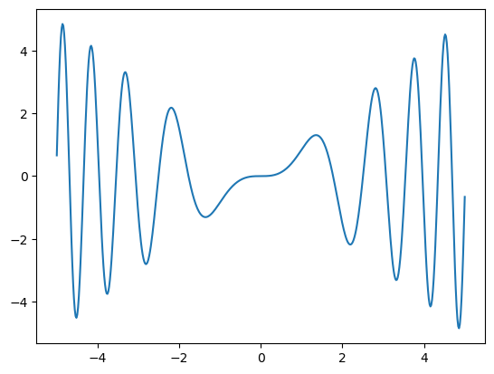

```python
plt.plot(x,y)
plt.show()
```

We can also customize the plot to include the title, axis labels, etc.

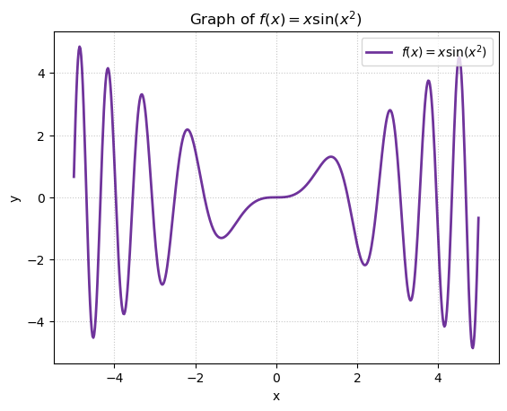

```python
plt.plot(x,y,
         label='$f(x) = x \\sin(x^{2})$',
         color='indigo',
         linewidth=2,
         alpha=0.8)
plt.title('Graph of $f(x) = x \\sin(x^{2})$')
plt.xlabel('x')
plt.ylabel('y')
plt.legend(loc='upper right')
plt.grid(True, linestyle=':', alpha=0.7)
plt.show()
```

### Example

We can also plot multiple functions in one axis. Let us plot $f(x) = x \sin(x^{2})$ and $g(x) = x^{2}\cos(x)$ over the same interval as above.

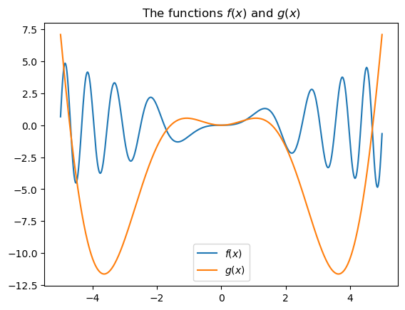

```python
x = np.linspace(-5,5,500)
y_f = x * np.sin(x**2)
y_g = x**2 * np.cos(x)

plt.plot(x,y_f, label='$f(x)$')
plt.plot(x,y_g, label='$g(x)$')
plt.title('The functions $f(x)$ and $g(x)$')
plt.legend()
```

## Subplots

We may plot multiple functions on different axes using `subplot`.

We need first to create a figure, then add to it the subplots.

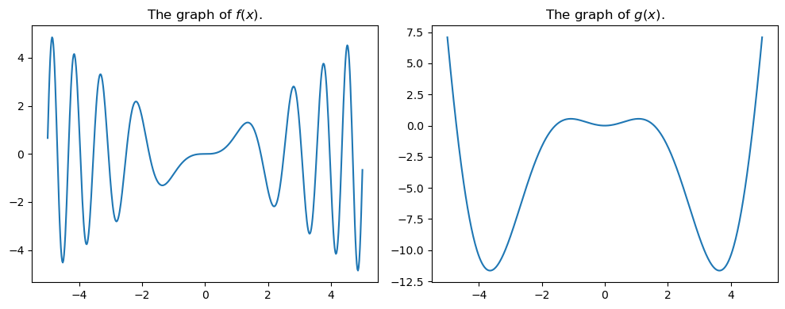

```python
fig = plt.figure(figsize=(10,4))
ax1 = fig.add_subplot(1,2,1)
ax1.plot(x,y_f)
ax1.set_title('The graph of $f(x)$.')

ax2 = fig.add_subplot(1,2,2)
ax2.plot(x,y_g)
ax2.set_title('The graph of $g(x)$.')

plt.tight_layout()
plt.show()
```

## Graph of a function of two variables (3D surface plot)

We need an additional 3D toolkit.

```python
from mpl_toolkits.mplot3d import Axes3D
```

### Example

Let us now plot the function $f(x,y) = \dfrac{ \sin(\sqrt{ x^{2} + y^{2} }) }{ \sqrt{ x^{2} + y^{2} } }$.

First, we make the grids of $x$ and $y$ and calculate $z = f(x,y)$ on these grid poitns.

```python
x = np.linspace(-5,5,500)
y = np.linspace(-5,5,500)
X, Y = np.meshgrid(x,y)

R = np.sqrt(X**2 + Y**2)
Z = np.sin(R) / R
```

Next, we continue with the plot. The first step is to create a `figure` and inside that, we create a 3D axis. After that, we create the surface and show the plot.

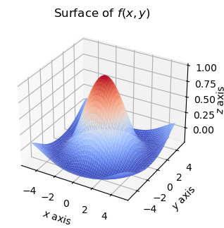

```python
# Create a figure and an empty axis inside it.
fig = plt.figure(figsize=(10,3), constrained_layout=True)
ax = fig.add_subplot(111, projection='3d')

# Plot the surface inside the axis.
ax.plot_surface(X,Y,Z,
               cmap='coolwarm')

# Customization
ax.set_title('Surface of $f(x,y)$')
ax.set_xlabel('$x$ axis')
ax.set_ylabel('$y$ axis')
ax.set_zlabel('$z$ axis')
ax.zaxis.labelpad = 1

# Show the surface.
plt.show()
```

### Example

Let us also demonstrate 2x2 subplots containing the graphs of $f(x) = x \sin(x^{2})$, $g(x) = x^{2} \cos(x)$, $h(x,y) = \dfrac{ \sin(\sqrt{ x^{2} + y^{2} }) }{ \sqrt{ x^{2} + y^{2} } }$ and $k(x,y) = \dfrac{1}{4}x^{2} - 2xy + 2y^{2}$.

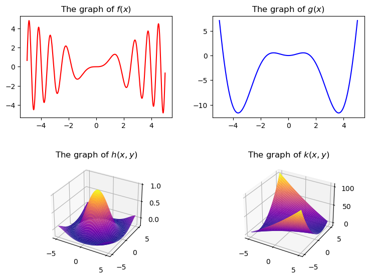

```python
fig3 = plt.figure(figsize=(8,6))

x2d = np.linspace(-5,5,500)
y2d_f = x * np.sin(x**2)
y2d_g = x**2 * np.cos(x)

ax1 = fig3.add_subplot(2,2,1)
ax1.plot(x2d, y2d_f, color='red')
ax1.set_title('The graph of $f(x)$')

ax2 = fig3.add_subplot(2,2,2)
ax2.plot(x2d, y2d_g, color='blue')
ax2.set_title('The graph of $g(x)$')

x3d = np.linspace(-5,5,500)
y3d = np.linspace(-5,5,500)
X, Y = np.meshgrid(x3d,y3d)
R = np.sqrt(X**2 + Y**2)
Z_h = np.sin(R) / R
Z_k = .25*X**2 - 2*X*Y + 2*Y**2
ax3 = fig3.add_subplot(2,2,3, projection='3d')
ax3.plot_surface(X, Y, Z_h, cmap='plasma')
ax3.set_title('The graph of $h(x,y)$')

ax4 = fig3.add_subplot(2,2,4, projection='3d')
ax4.plot_surface(X, Y, Z_k, cmap='plasma')
ax4.set_title('The graph of $k(x,y)$')

plt.tight_layout(pad=3.0)
plt.show()
```